# ESTUDIO DE POTENCIALIDADES DE URBANPY

## Carga de la libreria URBANPY

```python
import urbanpy as up
```

Consulta a la ayuda de la opcion de descarga de la libreria para conocer sus opciones

```python
help(up.download)
```

```
Help on package urbanpy.download in urbanpy:

NAME
    urbanpy.download

PACKAGE CONTENTS
    download

FUNCTIONS
    hdx_dataset(resource)
        Download a dataset from HDX. The allowed formats are CSV (.csv) and zipped
        CSV (.csv.zip).

        Parameters
        ----------
        resource: str
            Specific address to the HDX dataset resource. Since every dataset is
            referenced to a diferent resource id, only the base url can be provided
            by this library.

        Returns
        -------
        dataset: DataFrame
            Contains the requested HDX dataset resource.

        Examples
        --------
        >>> hdx_data = hdx_dataset('4e74db39-87f1-4383-9255-eaf8ebceb0c9/resource/317f1c39-8417-4bde-a076-99bd37feefce/download/population_per_2018-10-01.csv.zip')
        >>> hdx_data.head()
        latitude   | longitude  | population_2015 | population_2020
        -18.339306 | -70.382361 | 11.318147       | 12.099885
        -18.335694 | -70.393750 | 11.318147       | 12.099885
        -18.335694 | -70.387361     | 11.318147           | 12.099885
        -18.335417 | -70.394028     | 11.318147           | 12.099885
        -18.335139 | -70.394306     | 11.318147           | 12.099885

    hdx_fb_population(country, map_type)
        Download population density maps from Facebook HDX.

        Parameters
```

[output cut: 101 more lines]

```
        --------
        >>> lima = nominatim_osm('Lima, Peru', 2)
        >>> urbanpy.download.overpass_pois(lima.total_bounds, 'health')
        type |  id        | lat           | lon            | tags                                              | geometry                   | poi_type
        node |      367826732 |     -0.944005 |     -80.733941 | {'amenity': 'pharmacy', 'name': 'Fybeca'}         | POINT (-80.73394 -0.94401)     | pharmacy
        node |      367830051 |     -0.954086 |     -80.742420 | {'amenity': 'hospital', 'emergency': 'yes', 'n... | POINT (-80.74242 -0.95409)     | hospital
        node |      367830065 |     -0.954012 |     -80.741554 | {'amenity': 'hospital', 'name': 'Clínica del S... | POINT (-80.74155 -0.95401)     | hospital
        node |      367830072 |     -0.953488 |     -80.740739 | {'amenity': 'hospital', 'name': 'Clínica Cente... | POINT (-80.74074 -0.95349)     | hospital
        node |      3206491590|     -1.040708 |     -80.665107 | {'amenity': 'hospital', 'name': 'Clínica Monte... | POINT (-80.66511 -1.04071)     | hospital

DATA
    __all__ = ['nominatim_osm', 'hdx_dataset', 'hdx_fb_population', 'overp...

FILE
    c:\users\jfno8\anaconda3\lib\site-packages\urbanpy\download\__init__.py
```

**Resumen:**

La función hdx_dataset permite descargar datos desde el servicio HDX (Humanitarian Data Exchange) del Centro de Datos Humanitarios, https://data.humdata.org/faq.

La función hdx_fb_population, que descarga datos de densidad de población del servicio de Facebook de algunos paises dentro de los que no se encuentra enlistado Costa Rica, solo los siguientes: Argentina, Bolivia, Brazil, Chile, Colombia, Ecuador, Paraguay, Peru, Uruguay.

La función nominatim_osm permite la descarga de datos de una ciudad bajo la consulta a la fuente OSM. Por ejemplo: se pueden descargar los límites de la ciudad de San José.

La función osmnx_graph que se emplea en la descarga de datos viales.

Por último, la función overpass_pois que permite la descarga de algunas facilidades mapeadas en OSM, como lo son establecimientos relacionados a: comidas, salud, educacion y finanzas.

## Estudio con los datos de puntos propuestos para Color Vision

### Carga de algunas librerias necesarias.

```python
from shapely.geometry import Point, LineString, Polygon, box
import osmnx as ox
import geopandas as gpd
import pandas as pd
import numpy as np
import matplotlib.pyplot as plt
import contextily as cx
import plotly.express as px
```

### Carga de datos del estudio de ubicaciones sugeridas.

```python
dfp = pd.read_excel('G:/Trabajos Fran/color_vision/ubicaciones_sugeridas_vallasp.xlsx', sheet_name= 'datos', header= 4, usecols= ("A:L"), index_col= 0)
```

```python
dfp.head()
```

[output not shown]

```python
gdf = gpd.GeoDataFrame(
    dfp, geometry=gpd.points_from_xy(dfp.lon, dfp.lat), crs="EPSG:4326"
)
gdf.head()
```

[output not shown]

### Selección de uno de los puntos del muestreo.

```python
pt = gdf.iloc[[35]]
pt
```

[output not shown]

### Creación de un área de influencia de 1 km alrededor de punto para establecer una busqueda de facilidades cercanas al punto evaluado.

```python
pt_1 = pt.to_crs(8908)
bf_1 = pt_1.buffer(1000)
```

```python
pt_2 = pt_1.to_crs(4326)
bf_2 = bf_1.to_crs(4326)
```

### Prepación del mapa para visualizar la información.

```python
import folium
import leafmap
```

```python
map = folium.Map(location= [9.93141,-84.10749],tiles="CartoDB Positron", zoom_start=15)

folium.GeoJson(pt_2).add_to(map)
folium.GeoJson(bf_2).add_to(map)

map
```

Make this Notebook Trusted to load map: File -> Trust Notebook

[interactive chart not shown]

### Consulta con la función overpass_pois.

```python
help(up.download.overpass_pois)
```

```
Help on function overpass_pois in module urbanpy.download.download:

overpass_pois(bounds, facilities=None, custom_query=None)
    Download POIs using Overpass API.

    Parameters
    ----------
    bounds: array_like
        Input bounds for query. Follows [minx,miny,maxx,maxy] pattern.
    facilities: str. One of {'food', 'health', 'education', 'finance'}
        Type of facilities to download according to HOTOSM types. Based on this
        a different type of query is constructed.
    custom_query: str (Optional). Default None.
        String with custom Overpass QL query (See https://wiki.openstreetmap.org/wiki/Overpass_API/Language_Guide).
        If this parameter is diferent than None, bounds and facilities values
        are ignored.

    Returns
    -------
    gdf: GeoDataFrame
        POIs from the selected type of facility. If 'custom_query' is given
        response is returned instead of gdf.
    response: request.Response
        Returned only if 'custom_query' is given. Contains the server's response
        to the HTTP request from the Overpass API Server.

    Examples
    --------
    >>> lima = nominatim_osm('Lima, Peru', 2)
    >>> urbanpy.download.overpass_pois(lima.total_bounds, 'health')
    type |  id        | lat           | lon            | tags                                              | geometry                   | poi_type
    node |      367826732 |     -0.944005 |     -80.733941 | {'amenity': 'pharmacy', 'name': 'Fybeca'}         | POINT (-80.73394 -0.94401)     | pharmacy
    node |      367830051 |     -0.954086 |     -80.742420 | {'amenity': 'hospital', 'emergency': 'yes', 'n... | POINT (-80.74242 -0.95409)     | hospital
    node |      367830065 |     -0.954012 |     -80.741554 | {'amenity': 'hospital', 'name': 'Clínica del S... | POINT (-80.74155 -0.95401)     | hospital
    node |      367830072 |     -0.953488 |     -80.740739 | {'amenity': 'hospital', 'name': 'Clínica Cente... | POINT (-80.74074 -0.95349)     | hospital
    node |      3206491590|     -1.040708 |     -80.665107 | {'amenity': 'hospital', 'name': 'Clínica Monte... | POINT (-80.66511 -1.04071)     | hospital
```

```python
gdf_pois = up.download.overpass_pois(bf_2.total_bounds, 'food')
gdf_pois
```

[output not shown]

```python
gdf_pois = pd.concat([gdf_pois, gdf_pois["tags"].apply(pd.Series)], axis=1)
gdf_pois = gdf_pois.loc[:,['id','lat','lon','geometry','poi_type','name']]
gdf_pois
```

[output not shown]

```python
gdf_pois = gdf_pois.set_crs("EPSG:4326")
```

```python
for i in range(0,len(gdf_pois)):
   folium.Marker(
      location=[gdf_pois.iloc[i]['lat'], gdf_pois.iloc[i]['lon']],
      popup=gdf_pois.iloc[i]['name'],
      icon= folium.Icon(color='lightgray', icon='store', prefix='fa')
   ).add_to(map)
map
```

Make this Notebook Trusted to load map: File -> Trust Notebook

[interactive chart not shown]

### Consulta con la función hdx_dataset

```python
help(up.download.hdx_dataset)
```

```
Help on function hdx_dataset in module urbanpy.download.download:

hdx_dataset(resource)
    Download a dataset from HDX. The allowed formats are CSV (.csv) and zipped
    CSV (.csv.zip).

    Parameters
    ----------
    resource: str
        Specific address to the HDX dataset resource. Since every dataset is
        referenced to a diferent resource id, only the base url can be provided
        by this library.

    Returns
    -------
    dataset: DataFrame
        Contains the requested HDX dataset resource.

    Examples
    --------
    >>> hdx_data = hdx_dataset('4e74db39-87f1-4383-9255-eaf8ebceb0c9/resource/317f1c39-8417-4bde-a076-99bd37feefce/download/population_per_2018-10-01.csv.zip')
    >>> hdx_data.head()
    latitude   | longitude  | population_2015 | population_2020
    -18.339306 | -70.382361 | 11.318147       | 12.099885
    -18.335694 | -70.393750 | 11.318147       | 12.099885
    -18.335694 | -70.387361     | 11.318147           | 12.099885
    -18.335417 | -70.394028     | 11.318147           | 12.099885
    -18.335139 | -70.394306     | 11.318147           | 12.099885
```

Al observar la información que brinda la ayuda de esta función, confirmamos que solo es posible descargar datos en formato CSV desde el sitio web HDX, por lo que es importante confirmar los datos disponibles en dicho formato en la siguiente dirección: https://data.humdata.org/dataset/?groups=cri&res_format=CSV&q=&sort=last_modified%20desc&ext_page_size=25.  
A continuación, un ejemplo de esto.

```python
gdf_hdx = up.download.hdx_dataset('852b693f-4bf4-435e-a9aa-e1ddc33fa74e/resource/62839887-958e-434b-877a-c0410896d867/download/social-development_cri.csv')
```

```python
gdf_hdx.head()
```

[output not shown]

```python
import plotly.express as px
```

```python
gdf_hdx = gdf_hdx.iloc[1:].sort_values(by=['Year'])

gdf_hdx_1 = gdf_hdx[gdf_hdx['Indicator Name'].str.contains('rate', regex= True, na=False)]
fig = px.line(gdf_hdx_1, x='Year', y='Value', color='Indicator Name')
fig.show()
```

[output not shown]

Aunque la condición de formato de archivo (csv, zip) evidencian que los datos en dicha disposición son muy pocos a nivel país, si resulta interesante que desde esta fuente son consultables y descargables otros datos que estan disponibles en otros formatos en dicho sitio, como los datos de movilidad que proporciona META (https://dataforgood.facebook.com/dfg/tools), o los que figuran en WorldPop hub (https://hub.worldpop.org/project/list) o cualquier otra fuente disponible en este sitio.

A continuación, se realiza una consulta de las bases de datos disponibles en el sitio web del Centre for Humanitarian Data (HDX).

```python
from bs4 import BeautifulSoup
import requests
```

```python
url = "https://data.humdata.org/group/cri"

def scrape_page(url):
    response = requests.get(url)
    soup = BeautifulSoup(response.content, "html.parser")

    dataset_headings = [elem.text.strip() for elem in soup.find_all(class_="dataset-heading")]
    summaries = [elem.text.strip() for elem in soup.find_all(class_="dataset-description")]
    dataset_others = [elem.text.strip() for elem in soup.find_all(class_="dataset-others")]

    max_length = max(len(dataset_headings), len(summaries), len(dataset_others))
    dataset_headings += [None] * (max_length - len(dataset_headings))
    summaries += [None] * (max_length - len(summaries))
    dataset_others += [None] * (max_length - len(dataset_others))

    df = pd.DataFrame({
        "Dataset": dataset_headings,
        "Descripcion": summaries,
        "Formatos": dataset_others
    })

    return df

base_url = "https://data.humdata.org/group/cri"
num_pages = 5

all_dataframes = []
for page_num in range(1, num_pages + 1):
    page_url = f"{base_url}?page={page_num}"
    df = scrape_page(page_url)
    if df is not None:
        all_dataframes.append(df)

final_df = pd.concat(all_dataframes, ignore_index=True)
```

```python
from itables import init_notebook_mode, show

init_notebook_mode(all_interactive=True)
```

#### Tabla de información disponible en el sitio web (https://data.humdata.org/group/cri)

```python
show(final_df,
    layout={"top1": "searchBuilder"},
    columnDefs=[{"width": "100px", "className": "dt-left", "targets": "_all"}],
    scrollX=True,
    style="width:1200px",
    autoWidth=False,
)
```

[output not shown]

### Consulta con la función nominatim_osm

```python
help(up.download.nominatim_osm)
```

```
Help on function nominatim_osm in module urbanpy.download.download:

nominatim_osm(query, expected_position=0)
    Download OpenStreetMaps data for a specific city.

    Parameters
    ----------
    query: str
        Query for city polygon data to be downloaded.
    expected_position: int 0:n
        Expected position of the polygon data within the Nominatim results.
        Default 0 (first result).

    Returns
    -------
    city: GeoDataFrame
        GeoDataFrame with the city's polygon as its geometry column.

    Examples
    --------
    >>> lima = nominatim_osm('Lima, Peru', 2)
    >>> lima.head()
    geometry     | place_id      | osm_type     | osm_id     | display_name     | place_rank  |  category | type               | importance     | icon
    MULTIPOLYGON | 235480647 | relation | 1944670.0  | Lima, Peru       | 12          |  boundary |     administrative | 0.703484       | https://nominatim.openstreetmap.org/images/map...
```

Lo que se logra con esta función es descargar elementos mapeados en el servicio Open Street Maps. A continuación, un ejemplo:

```python
gdf_nom = up.download.nominatim_osm('La Sabana, Mata Redonda, Costa Rica')
```

```python
gdf_nom = gdf_nom.set_crs("EPSG:4326")
```

```python
gdf_nom.head()
```

[output not shown]

```python
folium.GeoJson(data=gdf_nom,
    style_function=lambda feature: {
        "fillColor": "#ff0000",
        "color": "black",
        "weight": 2,
        "dashArray": "5, 5",
    },).add_to(map)
map
```

Make this Notebook Trusted to load map: File -> Trust Notebook

[interactive chart not shown]

### Consulta con la función osmnx_graph

Esta función cumple con el objetivo de descargar datos espaciales vectoriales (puntos, líneas y polígonos) de elementos mapeados en el servicio de Open Street Map. El fin último de la descarga de estos datos es realizar con ellos análisis espacial tipo redes como es el caso de Isocrónas.

```python
import osmnx as ox
```

```python
help(up.download.osmnx_graph)
```

```
Help on function osmnx_graph in module urbanpy.download.download:

osmnx_graph(download_type, network_type='drive', query_str=None, geom=None, distance=None, **kwargs)
    Download a graph from OSM using osmnx.

    Parameters
    ----------
    download_type: str. One of {'polygon', 'place', 'point'}
        Input download type. If polygon, the polygon parameter must be provided
        as a Shapely Polygon.
    network_type: str. One of {'drive', 'drive_service', 'walk', 'bike', 'all', 'all_private'}
        Network type to download. Defaults to drive.
    query_str: str (Optional).
        Only requiered for place type downloads. Query string to download a network.
    polygon: Shapely Polygon or Point (Optional).
        Polygon requiered for polygon type downloads, Point for place downloads.
        Polygons are used as bounds for network download, points as the center.
        with a distance buffer.
    distance: int
        Distance in meters to use as buffer from a point to download the network.

    Returns
    -------
    G: networkx.MultiDiGraph
        Requested graph with simplyfied geometries.

    Examples
    --------
    >>> poly = urbanpy.download.nominatim_osm('San Isidro, Peru')
    >>> G = urbanpy.download.osmnx_graph('polygon', geom=lima.loc[0,'geometry'])
    >>> G
    <networkx.classes.multidigraph.MultiDiGraph at 0x1a2ba08150>
```

A continuación, un ejemplo de descarga de datos para el área de Mata Redonda de Cantón Central de San José.

```python
gdf_osmnx = up.download.osmnx_graph( 'place', 'drive', 'mata redonda, costa rica')
```

```python
gdf_grilla = ox.project_graph(gdf_osmnx)
```

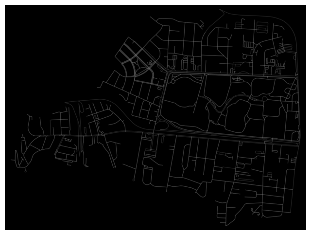

```python
fig, ax = ox.plot_graph(gdf_grilla, show=False, close=False, edge_color='#999999', edge_alpha=0.2, node_size=0, bgcolor='k')
```

### Otros

Otras funciones disponibles con esta libreria son las siguientes:

#### Accesibilidad

```python
help(up.accessibility)
```

```
Help on package urbanpy.accessibility in urbanpy:

NAME
    urbanpy.accessibility

PACKAGE CONTENTS
    accessibility

FUNCTIONS
    hu_access_map(units, pois, population_column, weight=1, d0=1250)
        Create accessibility surface from Hu et al. 2019. The authors provide an accessibility to healthy foods indicator that contemplates both the catchment area of a store and the access from a city block/district/county (denoted as E2SFCA).

        Parameters
        ----------
        units: GeoDataFrame
            Input spatial units to calculate access.

        pois: GeoDataFrame
            Input points of interest for access calculations

        population_column: str
            Key for population values in each spatial unit

        weight: int
            Weight for final indicator computation. Defaults to 1

        d0: int
            Buffer size. Defaults to 1250


        Returns
        -------
        access_map: GeoDataFrame
            Input unit dataframe with accessibility values.

        Examples
        --------
        >>> surface = urbanpy.accessibility.hu_access_map(blocks, pois, 'pop_2020')
        >>> surface.head()
        geometry     | place_id      | osm_type     | osm_id     | display_name     | place_rank  |  category | type               | importance     | icon
```

[output cut: 40 more lines]

```
            117        | 2.785714  |        POLYGON ((279276.449 8681335.243, 279323.599 8...
            41         | 20.500000 |    POLYGON ((313155.536 8677088.663, 313180.700 8...
            59         | 1.404762  |        POLYGON ((280125.735 8684068.209, 280098.318 8..


        References
        ----------

        Van Eck, J. R., & de Jong, T. (1999). Accessibility analysis and spatial competition effects in the context of GIS-supported service location planning. Computers, environment and urban systems, 23(2), 75-89.

DATA
    __all__ = ['pressure_map', 'hu_access_map']

FILE
    c:\users\jfno8\anaconda3\lib\site-packages\urbanpy\accessibility\__init__.py
```

El uso de esta función esta condicionada a que los datos de entrada sea con proyección cartográfica "EPSG:32718" la cual corresponde unicamente a los paises: Argentina, Brazil, Chile, Colombia, Ecuador, Peru.

#### La función geom

Esta función permite realizar lo que se conoce como [geoprocesos] lo cual corresponde con realizar uniones de datos con desde distintas tablas.

```python
help(up.geom)
```

```
Help on package urbanpy.geom in urbanpy:

NAME
    urbanpy.geom

PACKAGE CONTENTS
    geom

FUNCTIONS
    filter_population(pop_df, polygon_gdf)
        Filter an HDX database download to the polygon bounds

        Parameters
        ----------

        pop_df: DataFrame
                Result from download_hdx

        polygon_gdf: GeoDataFrame
                     Result from download_osm or merge_geom_downloads

        Returns
        -------

        filtered_points_gdf: GeoDataFrame
                             Population DataFrame filtered to polygon bounds

        Examples
        --------

        >>> lima = urbanpy.download.nominatim_osm("Lima, Peru", 2)
        >>> callao = urbanpy.download.nominatim_osm("Callao, Peru", 1)
        >>> lima = urbanpy.geom.merge_geom_downloads([lima, callao])
        >>> pop = urbanpy.download.hdx_fb_population('peru', 'full')
        >>> urbanpy.geom.filter_population(pop, lima)
        latitude   | longitude  | population_2015 | population_2020 | geometry
        -12.519861 | -76.774583 | 2.633668        | 2.644757        | POINT (-76.77458 -12.51986)
        -12.519861 | -76.745972 | 2.633668        | 2.644757        | POINT (-76.74597 -12.51986)
        -12.519861 | -76.745694 | 2.633668        | 2.644757        | POINT (-76.74569 -12.51986)
        -12.519861 | -76.742639 | 2.633668        | 2.644757        | POINT (-76.74264 -12.51986)
```

[output cut: 234 more lines]

```

        coarse_resolution: int, 0:15
                           Hexagon resolution lower than gdf actual resolution (higher values create smaller hexagons).

        Returns
        -------

        gdfc: GeoDataFrame
              GeoDataFrame with lower resolution hexagons geometry and metrics aggregated as indicated.

DATA
    __all__ = ['merge_geom_downloads', 'filter_population', 'remove_featur...

FILE
    c:\users\jfno8\anaconda3\lib\site-packages\urbanpy\geom\__init__.py
```

#### La función routing

Esta sirve para realizar cálculos de distancias y tiempos de recorrido entre puntos, dando como resultado una tabla matrix.

```python
help(up.routing)
```

```
Help on package urbanpy.routing in urbanpy:

NAME
    urbanpy.routing

PACKAGE CONTENTS
    routing

FUNCTIONS
    compute_osrm_dist_matrix(origins, destinations)
        Compute distance and travel time origin-destination matrices

        Parameters
        ----------

        origins: GeoDataFrame or GeoSeries
                 Input Point geometries corresponding to the starting points of a route.

        destinations: GeoDataFrame or GeoSeries
                      Point geometries corresponding to the end points of a route.

        Returns
        -------

        dist_matrix: array_like
                     Array with origins as rows and destinations as columns. Distance in meters.

        dur_matrix: array_like
                    Array with origins as rows and destinations as columns. Duration in minutes.

        Examples
        --------

        >>> hex = urbanpy.geom.gen_hexagons(8, lima)
        >>> fs = urbanpy.download.overpass_pois(hex.total_bounds, 'food_supply')
        >>> urbanpy.routing.start_osrm_server('peru', 'south-america')
        >>> dist, dur = urbanpy.routing.compute_osrm_dist_matrix(points.head(), fs.head(), 'walking')
        array([[ 82012.4,  93899.9,  88964.6, 111839.8,  87844. ],
           [ 26346.3,  23725.6,  19618.9,  38607.9,  22725.6],
           [ 26504.4,  23883.7,  19777. ,  38766. ,  22883.7],
```

[output cut: 320 more lines]

```

        profile: str. One of {'foot', 'car', 'bicycle'}
                 Travel mode to use when routing and estimating travel time.

        Examples
        --------

        >>> urbanpy.routing.stop_osrm_server('peru', 'south-america', 'foot')
        Server stopped succesfully

DATA
    __all__ = ['start_osrm_server', 'stop_osrm_server', 'osrm_route', 'goo...

FILE
    c:\users\jfno8\anaconda3\lib\site-packages\urbanpy\routing\__init__.py
```